# Relatedness Between Murray Cod Larvae 2011-2013

Alan Couch

Mon Jun 06 9:48:23 PM 2016

```
## Loading project configuration
```

```
## Autoloading helper functions
```

```
##  Running helper script: funRel.R
```

```
## Autoloading cache
```

```
## Autoloading data
```

```
##  Loading data set: DARTallIdentifiers
```

```
##  Loading data set: qslAllLarvaInfo
```

```
##  Loading data set: qslAllLarvaInfo2015
```

```
##  Loading data set: qslAllLarvaInfoApr2016
```

```
##  Loading data set: qslMPeeliiForRelated
```

```
##  Loading data set: Report.DMac15.1861
```

```
## Munging data
```

```
##  Running preprocessing script: 01MungeGeneticsData.R
```

```
##  Running preprocessing script: 02MungeLarvaSnpsByYears.R
```

```
##  Running preprocessing script: 03MungeLarvaSnpsByYearCombos.R
```

```r
a<-suppressPackageStartupMessages({
library(plyr)
library(dplyr)
library(digest)
library(igraph)
library(ggplot2)
library(data.table)
library(related)
})

ptm <- proc.time()
```

This calculates the relatedness between larvae within each year so as to identify full sibling pairs(FS) and half sibling pairs (HS). Unrelated (US) is also calculated by the ‘r’ package ‘related’. However we are interested only in FS at this stage to identify common parents and to assist with determining the distance of larval dispersal.

The same is finally calculated for all three years combined.

Because the genetic diversity is low, and there is likely inbreeding among the extant population, the inbreeding mode for ‘related’ is set to on. This makes calculations much slower, so estimators are not compared for combinations of larvae/adults or years.

# 2011 Larval Relatedness

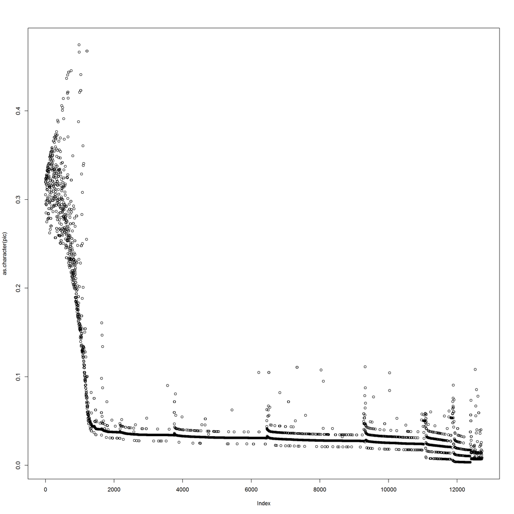

```r
#read 2011 subset of data in and change title for graphs.
df<-ellarvalPeeliSnps; main<-"2011 Larval snps"
df<-df[-c(1:4),]

pic<-df[2:nrow(df),14] #check pic in order
plot(as.character(pic))# to show PIC is in order (ish) ideally cut off would be 1300 or so.
```

```r
rm(pic)

#But choose only first 800 so PC does not crash
df<-df[-c(802:nrow(df))] #800 rows (they should be in order of PIC so the highest first)
```

```r
require(digest)
for (i in 1:length(df$X..2)) {
    df$unique[i] <- digest(df$X..2[i], algo = "xxhash32", seed = 1)
}
df <- cbind(df$unique, df)
names(df)[names(df) == "df$unique"] <- "allele"
df$unique <- NULL
df[1:10, c(1, 4)]
```

```
##       allele                                                                  X..2
## X5  a43f66cc                                                        AlleleSequence
## X6  127f06ec TGCAGGAGTCACGTTTCTCTCCCAAAACTCCCCTTAAGCTAAAAAACGTATAAATGAGAGCGTCAGCTA
## X7  756ac72f TGCAGGAGTCACGTTTCTCTCCCAAAACTCCCCTTAAGCTAAAAAACGTATAAATGAGAGTGTCAGCTA
## X8  648bd84a TGCAGAAATAAAGAACTTATTTTCAACCAACATGTCTTGTGATACCAAAGTTCTTTGGCCGCTATGTGC
## X9  9e1e8afc TGCAGAAATAAAGAATTTATTTTCAACCAACATGTCTTGTGATACCAAAGTTCTTTGGCCGCTATGTGC
## X10 d1899d1e TGCAGTGCTAATGCAGTTCGGAGGGCTTCTGCAATGCCTGTAAATGTGTACATGAGTATGTTTGTACAC
## X11 1beb420d TGCAGTGCTAATGCAGTTCGGGGGGCTTCTGCAATGCCTGTAAATGTGTACATGAGTATGTTTGTACAC
## X12 6a38a8f3 TGCAGTTGGACCCTTTGGTTGCCATTAGCCACGCTATCGTTTACTCCAGCTTTCCAAAACTGGGAAAGC
## X13 2630df0b TGCAGTTGGACCCTTTGGTTGCCATTAGCCACGCTATCGTTTACTCCAGCTTTCCAAAACTGGAAAAGC
## X14 c58a8999 TGCAGTTAACTCACCAAACTTTACTTTCCCACATTCCTAAAACCCCAGGCATTTGCATTATTTGAACCC
```

```r
df2 <- df
df2[2:18] <- list(NULL)
df2 <- setNames(data.frame(t(df2[, -1])), df2[, 1])
rownames(df2) <- df2[, 1]
fishID <- df2[, 1]
df2[, 1] <- NULL
colnames(df2) <- paste("X", colnames(df2), sep = "")
df2 <- as.data.frame(apply(df2, 2, function(x) gsub("\\s+", "", x)))
indx <- sapply(df2, is.factor)
df2[indx] <- lapply(df2[indx], function(x) as.numeric(as.character(x)))
rm(indx)
x <- df2
library(data.table)
setDT(x)
for (j in seq_along(x)) {
    set(x, i = which(x[[j]] == 1 & !is.na(x[[j]])), j = j, value = j)
}
d1 <- data.frame(x)
rm(x)
rm(i)
rm(j)
d1.lst <- lapply(seq(1, ncol(d1), by = 2), function(x) {
    return(d1[, x:(x + 1)])
})
d1.lst.fil <- lapply(d1.lst, function(x) {
    x[, 1][!is.na(x[, 1]) & x[, 1] == "0"] <- x[, 2][!is.na(x[, 1]) & x[, 1] == "0"]
    x[, 2][!is.na(x[, 2]) & x[, 2] == "0"] <- x[, 1][!is.na(x[, 2]) & x[, 2] == "0"]
    return(x)
})
df2 <- do.call(cbind, d1.lst.fil)
rm(d1)
rm(d1.lst)
rm(d1.lst.fil)
df2 <- cbind(fishID, df2)
rownames(df2) <- df2[, 1]
df2[, 1] <- NULL
write.table(df2[, 1:800], "outRelated.txt", sep = " ", col.names = FALSE, row.names = TRUE, quote = FALSE)
require(related)
input <- readgenotypedata("outRelated.txt")
output <- coancestry(input$gdata, allow.inbreeding = TRUE, trioml = 1, wang = 1, lynchli = 1, lynchrd = 1, ritland = 1, quellergt = 1, dyadml = 1)
```

```
##    user  system elapsed
##  202.63    0.17  203.63
##
## Reading output files into data.frames... Done!
```

```r
save(output, file = paste(c("output", main), collapse = " "))
write.table(output$relatedness, main, sep = ",", col.names = TRUE, row.names = TRUE)
head(output$relatedness)
```

```
##   pair.no ind1.id ind2.id group trioml   wang lynchli lynchrd ritland quellergt dyadml
## 1       1      70      71  7071 0.1046 0.1089  0.1117  0.1003  0.0975    0.1300 0.1046
## 2       2      70      72  7072 0.3040 0.2946  0.2972  0.3143  0.3123    0.3388 0.3040
## 3       3      70      73  7073 0.3796 0.4282  0.4283  0.3311  0.2792    0.3570 0.3824
## 4       4      70      76  7076 0.0000 0.2822  0.2746 -0.0572 -0.0389   -0.3511 0.0000
## 5       5      70      75  7075 0.3176 0.3872  0.3883  0.2201  0.1626    0.2224 0.3176
## 6       6      70      74  7074 0.1850 0.3435  0.3453  0.1428  0.1017    0.0541 0.1858
```

```r
head(output$inbreeding)
```

```
##   ind.id      LH      LR
## 1     70 -0.0216 -0.0231
## 2     71  0.0274  0.0271
## 3     72  0.1177  0.1201
## 4     73 -0.2108 -0.2117
## 5     76 -0.9080 -0.6277
## 6     75 -0.4029 -0.3945
```

So there are 400 loci being analysed. These are the first loci in the file ATM.

There are 62 individual fish in this set.

From the simulations of ‘known’ relationships we can choose cut off values for identifying relationships and colouring them in the matrix. In this case FS or PO above 0.4; HS 0.1-0.4; unrelated fish have a relatedness value below 0.15.

## Compare Estimators

```r
require(related)
compareestimators (input , 100)
```

```
##    user  system elapsed
##  140.29   17.44  212.22
##
## Reading output files into data.frames... Done!
##
## Correlation Coefficients Between Observed & Expected Values:
## wang     0.975596
## lynchli      0.975609
## lynchrd      0.978658
## quellergt    0.977586
```

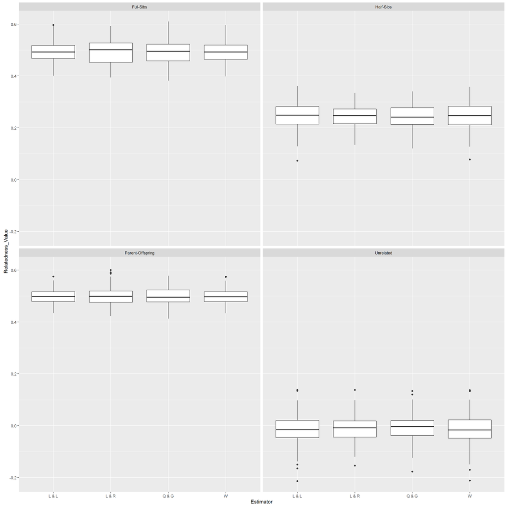

You can see there is not alot of difference between these estimators - at least with this number of loci.

## Plot relationships

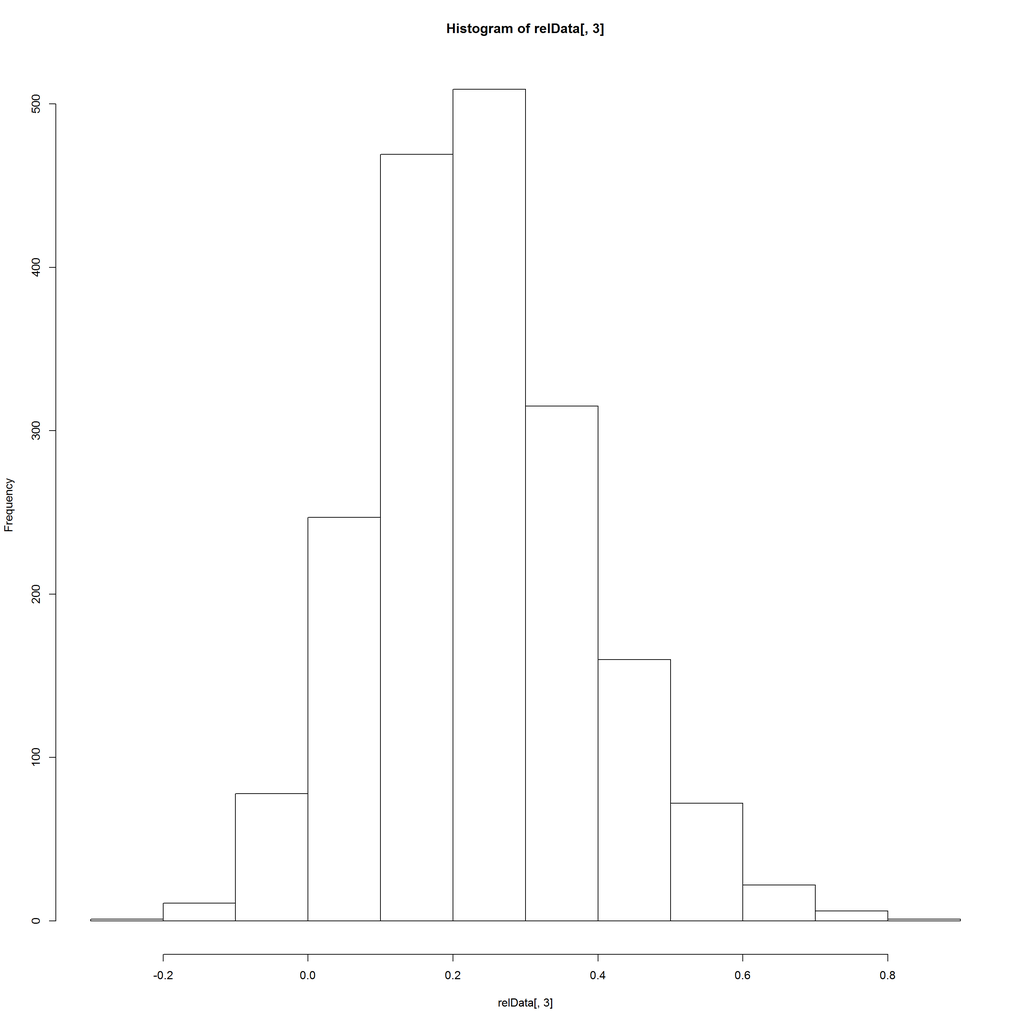

```r
require(igraph)

relData<-output$relatedness[,c(2,3,6)]
hist(relData[,3]) #to see how the data is distributed
```

```r
#Makes links DF
lrelData<-relData
colnames(lrelData)[1] <- "from"
colnames(lrelData)[2] <- "to"
colnames(lrelData)[3] <- "weight"
lrelData$type<-"probRel"

relDataNoRows<-nrow(relData) #get number of rows and store for later use.
#create new DF for nodes
nrelData <- data.frame(matrix(ncol = 4, nrow = relDataNoRows))
colnames(nrelData) <- c("id", "name", "type", "label")

#Populate the DF with the 'to' nodes from original list
nrelData[,1]<-relData[,2]
nrelData[,2]<-relData[,2]

#add the first entry from the 'from' list (otherwise it wont get in as it is not
# in the 'to list')
newrow = c(relData[1,1],relData[1,1],NA,NA)
nrelData = rbind(nrelData,newrow)

#have a look
head(nrelData)
```

```
##   id name type label
## 1 71   71 <NA>  <NA>
## 2 72   72 <NA>  <NA>
## 3 73   73 <NA>  <NA>
## 4 76   76 <NA>  <NA>
## 5 75   75 <NA>  <NA>
## 6 74   74 <NA>  <NA>
```

```r
head(lrelData)
```

```
##   from to weight    type
## 1   70 71 0.1089 probRel
## 2   70 72 0.2946 probRel
## 3   70 73 0.4282 probRel
## 4   70 76 0.2822 probRel
## 5   70 75 0.3872 probRel
## 6   70 74 0.3435 probRel
```

```r
nrow(nrelData); length(unique(nrelData$id))
```

```
## [1] 1892
```

```
## [1] 62
```

```r
nrow(lrelData); nrow(unique(lrelData[,c("from", "to")]))
```

```
## [1] 1891
```

```
## [1] 1891
```

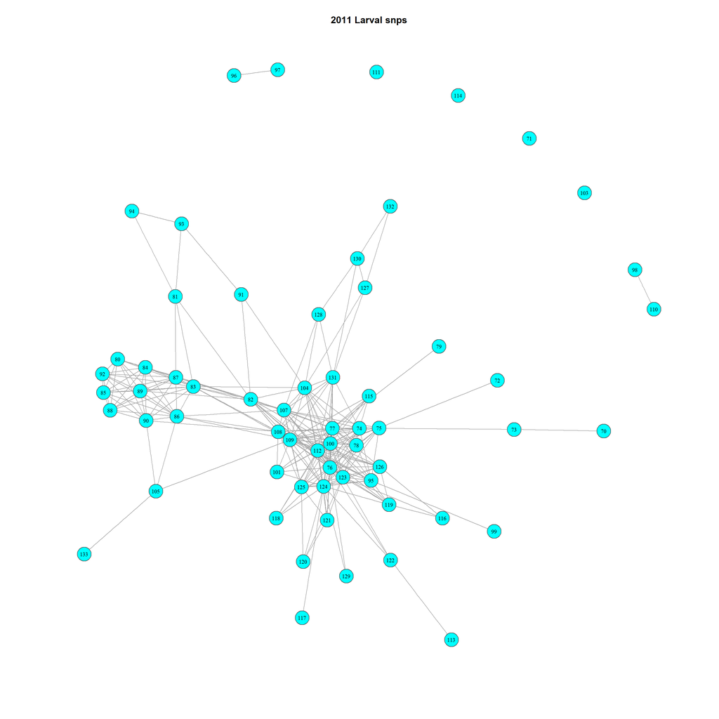

```r
nrelData<-data.frame(unique(nrelData[ , 1:4]))

#Apply types "adult" or "larvae" to fish based on id number.
tst<-ifelse(grepl("^A", nrelData$id),nrelData$type<-"adult",nrelData$type<-"larvae")
nrelData$type<-tst
rm(tst)

# Add data from larv to relatedNodes so that they are available for filtering on year etc.
larvNrel<-merge(nrelData,larv, by.x="id", by.y="LarvalRecords_LarvaID")
larvNrel<-larvNrel[,c(1:4,66)]

#Create the network data
net<-graph_from_data_frame(d=lrelData, vertices=nrelData, directed=FALSE)

# Generate colors for adults and larvae:
colrs <- c("tomato", "gold")
V(net)$color <- colrs[V(net)$type]

#Limit to full siblings - this also makes it more sparse.
net.FS <- delete_edges(net, E(net)[weight<0.4])
l <- layout_with_fr(net.FS)

plot(net.FS, edge.arrow.size=0, edge.curved=0, vertex.size=5,vertex.color=c("orange", "cyan")[(V(net.FS)$type=="larvae")+1], vertex.frame.color="#555555",vertex.label=V(net)$name, vertex.label.color="black",vertex.label.cex=.7,layout=l, main = main)
```

# 2012 Larval Relatedness

```r
#read file in
df<-twlarvalPeeliSnps; main<-"2012 Larval snps"
df<-df[-c(1:4),]
```

```
##       allele                                                                  X..2
## X5  a43f66cc                                                        AlleleSequence
## X6  127f06ec TGCAGGAGTCACGTTTCTCTCCCAAAACTCCCCTTAAGCTAAAAAACGTATAAATGAGAGCGTCAGCTA
## X7  756ac72f TGCAGGAGTCACGTTTCTCTCCCAAAACTCCCCTTAAGCTAAAAAACGTATAAATGAGAGTGTCAGCTA
## X8  648bd84a TGCAGAAATAAAGAACTTATTTTCAACCAACATGTCTTGTGATACCAAAGTTCTTTGGCCGCTATGTGC
## X9  9e1e8afc TGCAGAAATAAAGAATTTATTTTCAACCAACATGTCTTGTGATACCAAAGTTCTTTGGCCGCTATGTGC
## X10 d1899d1e TGCAGTGCTAATGCAGTTCGGAGGGCTTCTGCAATGCCTGTAAATGTGTACATGAGTATGTTTGTACAC
## X11 1beb420d TGCAGTGCTAATGCAGTTCGGGGGGCTTCTGCAATGCCTGTAAATGTGTACATGAGTATGTTTGTACAC
## X12 6a38a8f3 TGCAGTTGGACCCTTTGGTTGCCATTAGCCACGCTATCGTTTACTCCAGCTTTCCAAAACTGGGAAAGC
## X13 2630df0b TGCAGTTGGACCCTTTGGTTGCCATTAGCCACGCTATCGTTTACTCCAGCTTTCCAAAACTGGAAAAGC
## X14 c58a8999 TGCAGTTAACTCACCAAACTTTACTTTCCCACATTCCTAAAACCCCAGGCATTTGCATTATTTGAACCC
```

```
##    user  system elapsed
##   96.44    0.07   96.86
##
## Reading output files into data.frames... Done!
```

```
##   pair.no ind1.id ind2.id group trioml   wang lynchli lynchrd ritland quellergt dyadml
## 1       1     134     151  1315 0.0348 0.2803  0.2733 -0.1682 -0.1089   -0.2534 0.0348
## 2       2     134     157  1315 0.0000 0.1316  0.1300 -0.0812 -0.0627   -0.1137 0.0000
## 3       3     134     156  1315 0.0000 0.2247  0.2162 -0.0973 -0.0709   -0.1024 0.0000
## 4       4     134     155  1315 0.0830 0.3140  0.3093  0.0530  0.0386    0.0231 0.0835
## 5       5     134     154  1315 0.0500 0.3232  0.3206  0.0344  0.0242    0.0535 0.0508
## 6       6     134     153  1315 0.0000 0.1929  0.1892 -0.1547 -0.1097   -0.1787 0.0000
```

```
##   ind.id      LH      LR
## 1    134 -0.4981 -0.4440
## 2    151 -0.2954 -0.3054
## 3    157  0.0726  0.0781
## 4    156 -0.0363 -0.0398
## 5    155 -0.0510 -0.0552
## 6    154 -0.0422 -0.0500
```

So there are 400 loci being analysed. These are the first loci in the file ATM.

There are 46 individual fish in this set.

From the simulations of ‘known’ relationships we can choose cut off values for identifying relationships and colouring them in the matrix. In this case FS or PO above 0.4; HS 0.1-0.4; unrelated fish have a relatedness value below 0.15.

## Compare Estimators

```r
require(related)
compareestimators (input , 100)
```

```
##    user  system elapsed
##  143.72   17.13  217.08
##
## Reading output files into data.frames... Done!
##
## Correlation Coefficients Between Observed & Expected Values:
## wang     0.972770
## lynchli      0.972582
## lynchrd      0.978428
## quellergt    0.976392
```

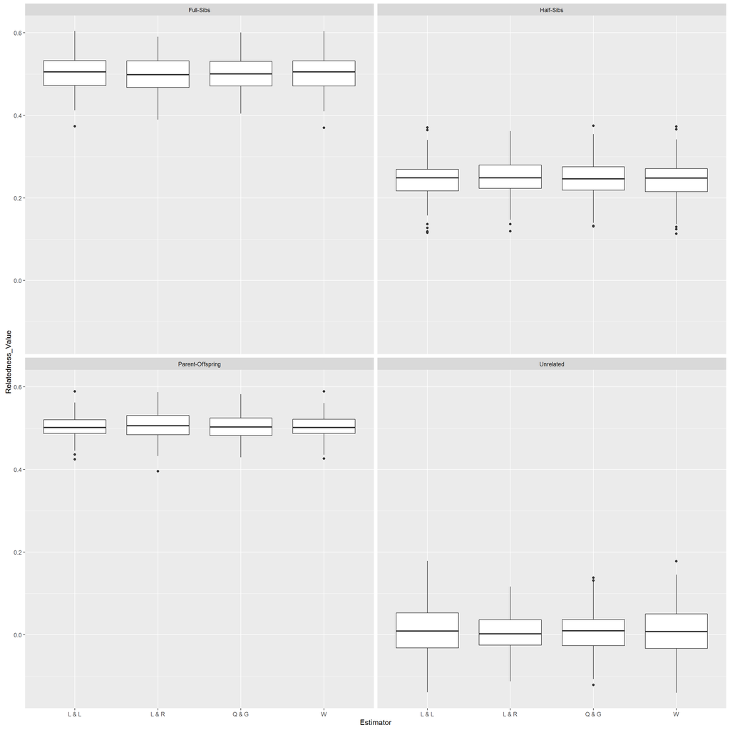

You can see there is not alot of difference between these estimators - at least with this number of loci.

## Plot relationships

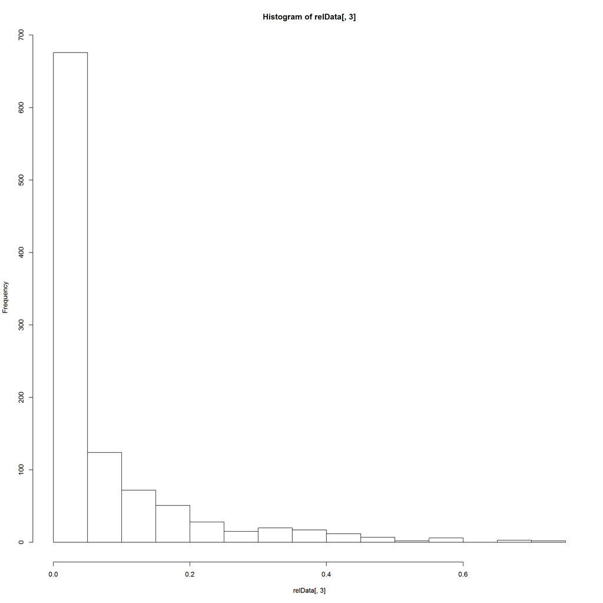

```r
require(igraph)

relData<-output$relatedness[,c(2,3,11)]
hist(relData[,3]) #to see how the data is distributed
```

```r
#Makes links DF
lrelData<-relData
colnames(lrelData)[1] <- "from"
colnames(lrelData)[2] <- "to"
colnames(lrelData)[3] <- "weight"
lrelData$type<-"probRel"

relDataNoRows<-nrow(relData) #get number of rows and store for later use.
#create new DF for nodes
nrelData <- data.frame(matrix(ncol = 4, nrow = relDataNoRows))
colnames(nrelData) <- c("id", "name", "type", "label")

#Populate the DF with the 'to' nodes from original list
nrelData[,1]<-relData[,2]
nrelData[,2]<-relData[,2]

#add the first entry from the 'from' list (otherwise it wont get in as it is not
# in the 'to list')
newrow = c(relData[1,1],relData[1,1],NA,NA)
nrelData = rbind(nrelData,newrow)

#have a look
head(nrelData)
```

```
##    id name type label
## 1 151  151 <NA>  <NA>
## 2 157  157 <NA>  <NA>
## 3 156  156 <NA>  <NA>
## 4 155  155 <NA>  <NA>
## 5 154  154 <NA>  <NA>
## 6 153  153 <NA>  <NA>
```

```r
head(lrelData)
```

```
##   from  to weight    type
## 1  134 151 0.0348 probRel
## 2  134 157 0.0000 probRel
## 3  134 156 0.0000 probRel
## 4  134 155 0.0835 probRel
## 5  134 154 0.0508 probRel
## 6  134 153 0.0000 probRel
```

```r
nrow(nrelData); length(unique(nrelData$id))
```

```
## [1] 1036
```

```
## [1] 46
```

```r
nrow(lrelData); nrow(unique(lrelData[,c("from", "to")]))
```

```
## [1] 1035
```

```
## [1] 1035
```

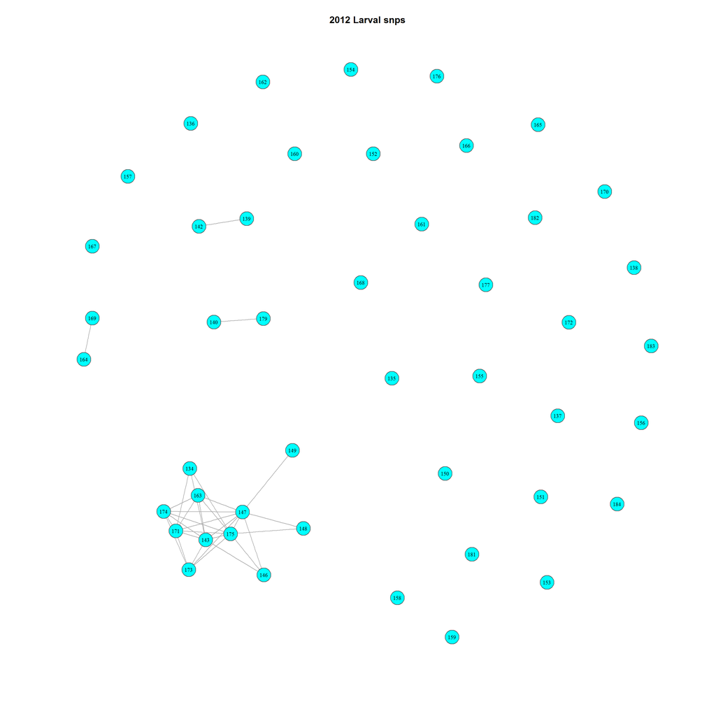

```r
nrelData<-data.frame(unique(nrelData[ , 1:4]))

#Apply types "adult" or "larvae" to fish based on id number.
tst<-ifelse(grepl("^A", nrelData$id),nrelData$type<-"adult",nrelData$type<-"larvae")
nrelData$type<-tst
rm(tst)

# Add data from larv to relatedNodes so that they are available for filtering on year etc.
larvNrel<-merge(nrelData,larv, by.x="id", by.y="LarvalRecords_LarvaID")
larvNrel<-larvNrel[,c(1:4,66)]

#Create the network data
net<-graph_from_data_frame(d=lrelData, vertices=nrelData, directed=FALSE)

# Generate colors for adults and larvae:
colrs <- c("tomato", "gold")
V(net)$color <- colrs[V(net)$type]

#Limit to full siblings - this also makes it more sparse.
net.FS <- delete_edges(net, E(net)[weight<0.4])
l <- layout_with_fr(net.FS)

plot(net.FS, edge.arrow.size=0, edge.curved=0, vertex.size=5,vertex.color=c("orange", "cyan")[(V(net.FS)$type=="larvae")+1], vertex.frame.color="#555555",vertex.label=V(net)$name, vertex.label.color="black",vertex.label.cex=.7,layout=l, main = main)
```

# 2013 Larval Relatedness

```r
#read 2013 subset in
df<-thlarvalPeeliSnps; main<-"2013 Larval snps"
df<-df[-c(1:4),]
```

```
##       allele                                                                  X..2
## X5  a43f66cc                                                        AlleleSequence
## X6  127f06ec TGCAGGAGTCACGTTTCTCTCCCAAAACTCCCCTTAAGCTAAAAAACGTATAAATGAGAGCGTCAGCTA
## X7  756ac72f TGCAGGAGTCACGTTTCTCTCCCAAAACTCCCCTTAAGCTAAAAAACGTATAAATGAGAGTGTCAGCTA
## X8  648bd84a TGCAGAAATAAAGAACTTATTTTCAACCAACATGTCTTGTGATACCAAAGTTCTTTGGCCGCTATGTGC
## X9  9e1e8afc TGCAGAAATAAAGAATTTATTTTCAACCAACATGTCTTGTGATACCAAAGTTCTTTGGCCGCTATGTGC
## X10 d1899d1e TGCAGTGCTAATGCAGTTCGGAGGGCTTCTGCAATGCCTGTAAATGTGTACATGAGTATGTTTGTACAC
## X11 1beb420d TGCAGTGCTAATGCAGTTCGGGGGGCTTCTGCAATGCCTGTAAATGTGTACATGAGTATGTTTGTACAC
## X12 6a38a8f3 TGCAGTTGGACCCTTTGGTTGCCATTAGCCACGCTATCGTTTACTCCAGCTTTCCAAAACTGGGAAAGC
## X13 2630df0b TGCAGTTGGACCCTTTGGTTGCCATTAGCCACGCTATCGTTTACTCCAGCTTTCCAAAACTGGAAAAGC
## X14 c58a8999 TGCAGTTAACTCACCAAACTTTACTTTCCCACATTCCTAAAACCCCAGGCATTTGCATTATTTGAACCC
```

```
##    user  system elapsed
##  577.92    0.50  580.78
##
## Reading output files into data.frames... Done!
```

```
##   pair.no ind1.id ind2.id group trioml   wang lynchli lynchrd ritland quellergt dyadml
## 1       1     185     186  1818 0.4440 0.4752  0.4769  0.4316  0.3883    0.4798 0.4495
## 2       2     185     187  1818 0.4804 0.4679  0.4753  0.4823  0.4569    0.5022 0.4836
## 3       3     185     188  1818 0.2943 0.3073  0.3163  0.3009  0.2774    0.3327 0.2968
## 4       4     185     189  1818 0.4476 0.4502  0.4562  0.4699  0.4567    0.4836 0.4503
## 5       5     185     190  1819 0.4536 0.4661  0.4721  0.4387  0.3914    0.4757 0.4559
## 6       6     185     191  1819 0.0000 0.0034  0.0078 -0.0574 -0.0526   -0.0010 0.0000
```

```
##   ind.id      LH      LR
## 1    185  0.0401  0.0456
## 2    186 -0.0380 -0.0413
## 3    187  0.0524  0.0567
## 4    188 -0.0006 -0.0006
## 5    189  0.0629  0.0649
## 6    190 -0.0157 -0.0177
```

So there are 400 loci being analysed. These are the first loci in the file ATM.

There are 135 individual fish in this set.

From the simulations of ‘known’ relationships we can choose cut off values for identifying relationships and colouring them in the matrix. In this case FS or PO above 0.4; HS 0.1-0.4; unrelated fish have a relatedness value below 0.15.

## Compare Estimators

```r
require(related)
compareestimators (input , 100)
```

```
##    user  system elapsed
##  142.17   17.69  214.24
##
## Reading output files into data.frames... Done!
##
## Correlation Coefficients Between Observed & Expected Values:
## wang     0.972128
## lynchli      0.972266
## lynchrd      0.976561
## quellergt    0.973811
```

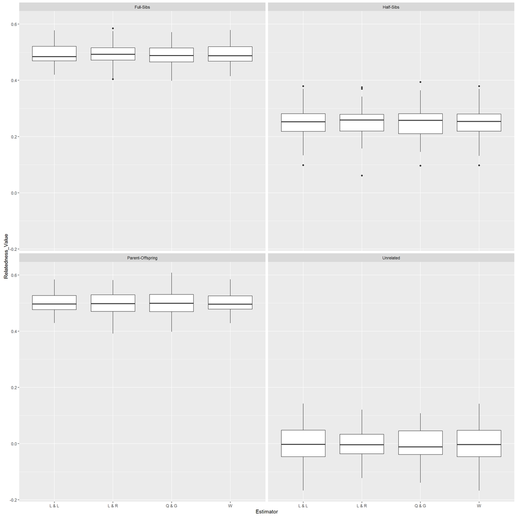

You can see there is not alot of difference between these estimators - at least with this number of loci.

## Plot relationships

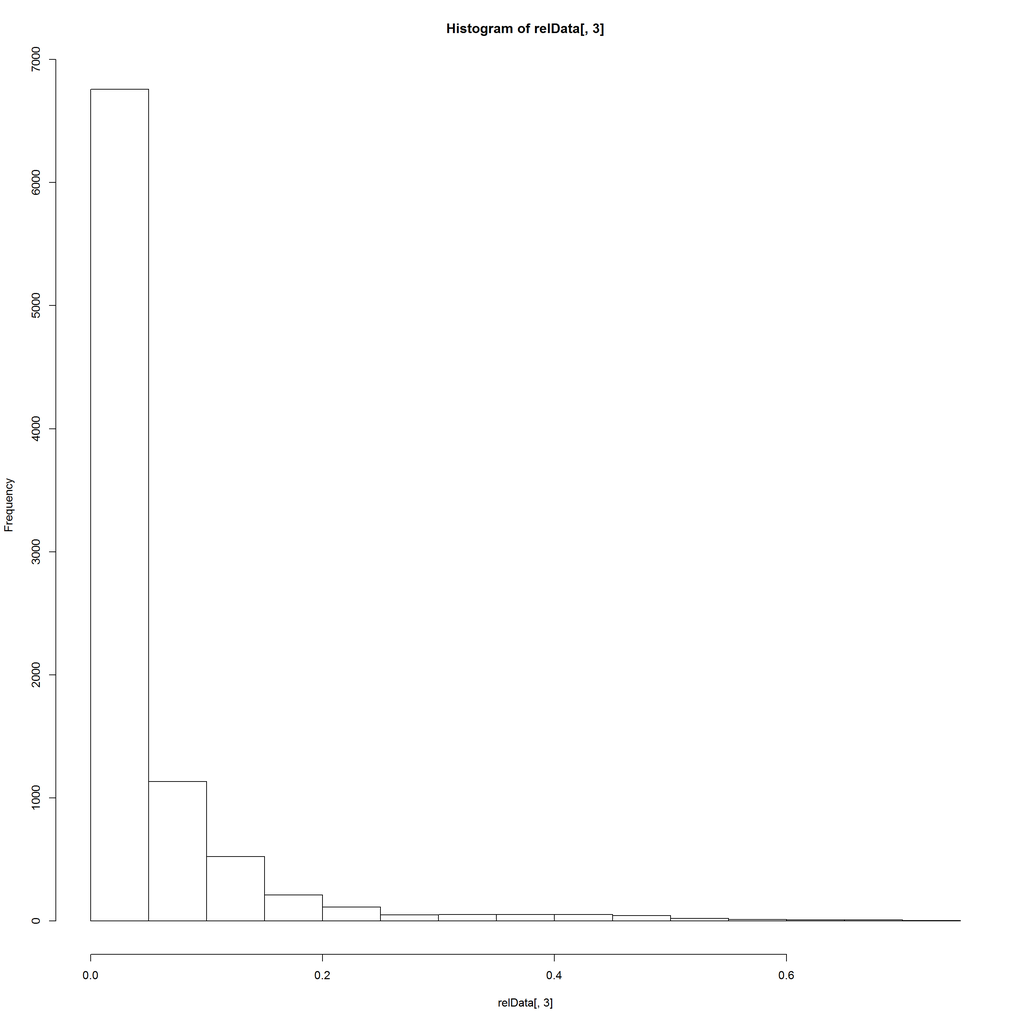

```r
require(igraph)

relData<-output$relatedness[,c(2,3,11)]
hist(relData[,3]) #to see how the data is distributed
```

```r
#Makes links DF
lrelData<-relData
colnames(lrelData)[1] <- "from"
colnames(lrelData)[2] <- "to"
colnames(lrelData)[3] <- "weight"
lrelData$type<-"probRel"

relDataNoRows<-nrow(relData) #get number of rows and store for later use.
#create new DF for nodes
nrelData <- data.frame(matrix(ncol = 4, nrow = relDataNoRows))
colnames(nrelData) <- c("id", "name", "type", "label")

#Populate the DF with the 'to' nodes from original list
nrelData[,1]<-relData[,2]
nrelData[,2]<-relData[,2]

#add the first entry from the 'from' list (otherwise it wont get in as it is not
# in the 'to list')
newrow = c(relData[1,1],relData[1,1],NA,NA)
nrelData = rbind(nrelData,newrow)

#have a look
head(nrelData)
```

```
##    id name type label
## 1 186  186 <NA>  <NA>
## 2 187  187 <NA>  <NA>
## 3 188  188 <NA>  <NA>
## 4 189  189 <NA>  <NA>
## 5 190  190 <NA>  <NA>
## 6 191  191 <NA>  <NA>
```

```r
head(lrelData)
```

```
##   from  to weight    type
## 1  185 186 0.4495 probRel
## 2  185 187 0.4836 probRel
## 3  185 188 0.2968 probRel
## 4  185 189 0.4503 probRel
## 5  185 190 0.4559 probRel
## 6  185 191 0.0000 probRel
```

```r
nrow(nrelData); length(unique(nrelData$id))
```

```
## [1] 9046
```

```
## [1] 135
```

```r
nrow(lrelData); nrow(unique(lrelData[,c("from", "to")]))
```

```
## [1] 9045
```

```
## [1] 9045
```

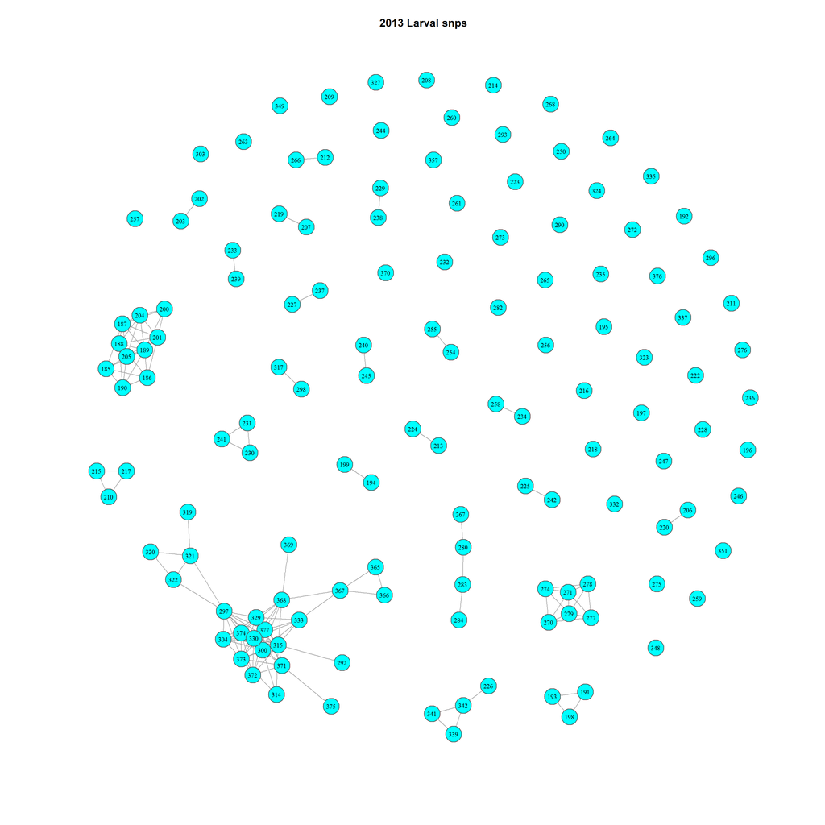

```r
nrelData<-data.frame(unique(nrelData[ , 1:4]))

#Apply types "adult" or "larvae" to fish based on id number.
tst<-ifelse(grepl("^A", nrelData$id),nrelData$type<-"adult",nrelData$type<-"larvae")
nrelData$type<-tst
rm(tst)

# Add data from larv to relatedNodes so that they are available for filtering on year etc.
larvNrel<-merge(nrelData,larv, by.x="id", by.y="LarvalRecords_LarvaID")
larvNrel<-larvNrel[,c(1:4,66)]

#Create the network data
net<-graph_from_data_frame(d=lrelData, vertices=nrelData, directed=FALSE)

# Generate colors for adults and larvae:
colrs <- c("tomato", "gold")
V(net)$color <- colrs[V(net)$type]

#Limit to full siblings - this also makes it more sparse.
net.FS <- delete_edges(net, E(net)[weight<0.4])
l <- layout_with_fr(net.FS)

plot(net.FS, edge.arrow.size=0, edge.curved=0, vertex.size=5,vertex.color=c("orange", "cyan")[(V(net.FS)$type=="larvae")+1], vertex.frame.color="#555555",vertex.label=V(net)$name, vertex.label.color="black",vertex.label.cex=.7,layout=l, main = main)
```

# 2011-2013 Larval Relatedness

```r
#read file/s in and generate dataset for sibling analysis
df<-larvalPeeliSnps; main<-"3 Years Larval snps"
df<-df[-c(1:4),]
```

```
##       allele                                                                  X..2
## X5  a43f66cc                                                        AlleleSequence
## X6  127f06ec TGCAGGAGTCACGTTTCTCTCCCAAAACTCCCCTTAAGCTAAAAAACGTATAAATGAGAGCGTCAGCTA
## X7  756ac72f TGCAGGAGTCACGTTTCTCTCCCAAAACTCCCCTTAAGCTAAAAAACGTATAAATGAGAGTGTCAGCTA
## X8  648bd84a TGCAGAAATAAAGAACTTATTTTCAACCAACATGTCTTGTGATACCAAAGTTCTTTGGCCGCTATGTGC
## X9  9e1e8afc TGCAGAAATAAAGAATTTATTTTCAACCAACATGTCTTGTGATACCAAAGTTCTTTGGCCGCTATGTGC
## X10 d1899d1e TGCAGTGCTAATGCAGTTCGGAGGGCTTCTGCAATGCCTGTAAATGTGTACATGAGTATGTTTGTACAC
## X11 1beb420d TGCAGTGCTAATGCAGTTCGGGGGGCTTCTGCAATGCCTGTAAATGTGTACATGAGTATGTTTGTACAC
## X12 6a38a8f3 TGCAGTTGGACCCTTTGGTTGCCATTAGCCACGCTATCGTTTACTCCAGCTTTCCAAAACTGGGAAAGC
## X13 2630df0b TGCAGTTGGACCCTTTGGTTGCCATTAGCCACGCTATCGTTTACTCCAGCTTTCCAAAACTGGAAAAGC
## X14 c58a8999 TGCAGTTAACTCACCAAACTTTACTTTCCCACATTCCTAAAACCCCAGGCATTTGCATTATTTGAACCC
```

```
##    user  system elapsed
## 2289.65    0.97 2296.77
##
## Reading output files into data.frames... Done!
```

```
##   pair.no ind1.id ind2.id group trioml   wang lynchli lynchrd ritland quellergt dyadml
## 1       1     185     186  1818 0.4619 0.4901  0.4910  0.4502  0.4125    0.5017 0.4637
## 2       2     185     187  1818 0.4937 0.4835  0.4894  0.4965  0.4787    0.5219 0.4971
## 3       3     185     188  1818 0.3104 0.3273  0.3346  0.3163  0.2947    0.3581 0.3144
## 4       4     185     189  1818 0.4589 0.4665  0.4708  0.4862  0.4820    0.5046 0.4623
## 5       5     185     190  1819 0.4679 0.4814  0.4863  0.4579  0.4168    0.4975 0.4702
## 6       6     185     191  1819 0.0000 0.0290  0.0345 -0.0374 -0.0339    0.0327 0.0000
```

```
##   ind.id      LH      LR
## 1    185  0.0562  0.0636
## 2    186 -0.0227 -0.0247
## 3    187  0.0676  0.0732
## 4    188  0.0115  0.0126
## 5    189  0.0825  0.0851
## 6    190 -0.0014 -0.0016
```

So there are 400 loci being analysed. These are the first loci in the file ATM.

There are 243 individual fish in this set. From the simulations of ‘known’ relationships we can choose cut off values for identifying relationships and colouring them in the matrix. In this case FS or PO above 0.4; HS 0.1-0.4; unrelated fish have a relatedness value below 0.15.

## Plot relationships

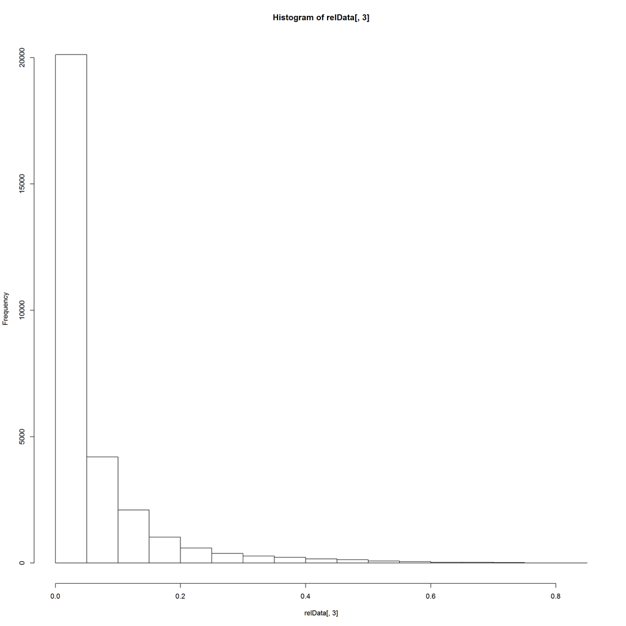

```r
require(igraph)

relData<-output$relatedness[,c(2,3,11)]
hist(relData[,3]) #to see how the data is distributed
```

```r
#Makes links DF
lrelData<-relData
colnames(lrelData)[1] <- "from"
colnames(lrelData)[2] <- "to"
colnames(lrelData)[3] <- "weight"
lrelData$type<-"probRel"

relDataNoRows<-nrow(relData) #get number of rows and store for later use.
#create new DF for nodes
nrelData <- data.frame(matrix(ncol = 4, nrow = relDataNoRows))
colnames(nrelData) <- c("id", "name", "type", "label")

#Populate the DF with the 'to' nodes from original list
nrelData[,1]<-relData[,2]
nrelData[,2]<-relData[,2]

#add the first entry from the 'from' list (otherwise it wont get in as it is not
# in the 'to list')
newrow = c(relData[1,1],relData[1,1],NA,NA)
nrelData = rbind(nrelData,newrow)

#have a look
head(nrelData)
```

```
##    id name type label
## 1 186  186 <NA>  <NA>
## 2 187  187 <NA>  <NA>
## 3 188  188 <NA>  <NA>
## 4 189  189 <NA>  <NA>
## 5 190  190 <NA>  <NA>
## 6 191  191 <NA>  <NA>
```

```r
head(lrelData)
```

```
##   from  to weight    type
## 1  185 186 0.4637 probRel
## 2  185 187 0.4971 probRel
## 3  185 188 0.3144 probRel
## 4  185 189 0.4623 probRel
## 5  185 190 0.4702 probRel
## 6  185 191 0.0000 probRel
```

```r
nrow(nrelData); length(unique(nrelData$id))
```

```
## [1] 29404
```

```
## [1] 243
```

```r
nrow(lrelData); nrow(unique(lrelData[,c("from", "to")]))
```

```
## [1] 29403
```

```
## [1] 29403
```

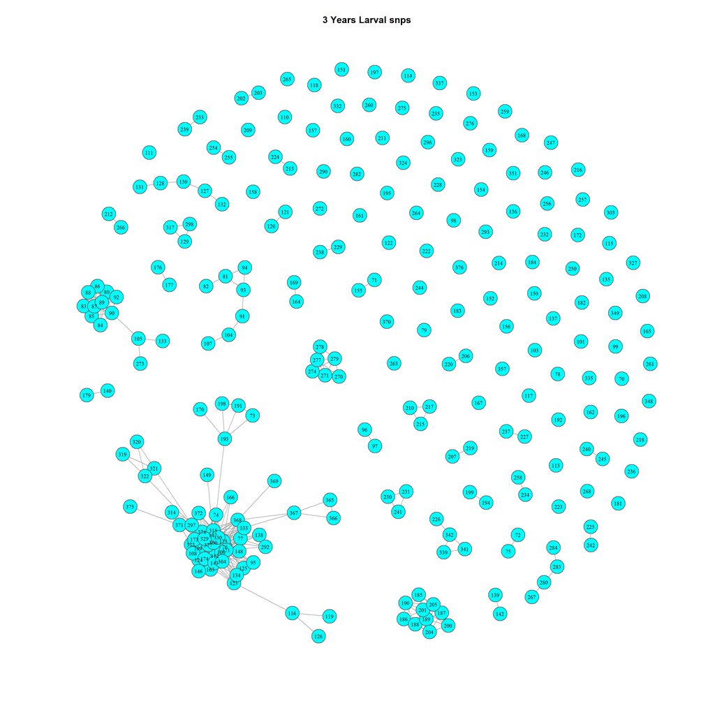

```r
nrelData<-data.frame(unique(nrelData[ , 1:4]))

#Apply types "adult" or "larvae" to fish based on id number.
tst<-ifelse(grepl("^A", nrelData$id),nrelData$type<-"adult",nrelData$type<-"larvae")
nrelData$type<-tst
rm(tst)

# Add data from larv to relatedNodes so that they are available for filtering on year etc.
larvNrel<-merge(nrelData,larv, by.x="id", by.y="LarvalRecords_LarvaID")
larvNrel<-larvNrel[,c(1:4,66)]

#Create the network data
net<-graph_from_data_frame(d=lrelData, vertices=nrelData, directed=FALSE)

# Generate colors for adults and larvae:
colrs <- c("tomato", "gold")
V(net)$color <- colrs[V(net)$type]

#Limit to full siblings - this also makes it more sparse.
net.FS <- delete_edges(net, E(net)[weight<0.4])
l <- layout_with_fr(net.FS)

plot(net.FS, edge.arrow.size=0, edge.curved=0, vertex.size=5,vertex.color=c("orange", "cyan")[(V(net.FS)$type=="larvae")+1], vertex.frame.color="#555555",vertex.label=V(net)$name, vertex.label.color="black",vertex.label.cex=.7,layout=l, main = main)
```

```r
all_labels()
```

```
##  [1] "Project_Template_and_Knitr"                   "Set_Global_Options"                           "unnamed-chunk-1"                              "unnamed-chunk-2"
##  [5] "Sibling Relationships in 2011 Larvae"         "Larvae2011"                                   "Compare the estimators"                       "Plot Relationship Nets using iGraph"
##  [9] "Sibling Relationships in 2012 Larvae"         "Larvae2012"                                   "unnamed-chunk-3"                              "unnamed-chunk-4"
## [13] "Sibling Relationships in 2013 Larvae"         "Larvae2013"                                   "unnamed-chunk-5"                              "unnamed-chunk-6"
## [17] "Sibling Relationships in 3 years Larvae"      "LarvaeAllYears"                               "unnamed-chunk-7"                              "Include_Chunk_Labels_and_Session Information"
## [21] "related"
```

```r
proc.time()-ptm
```

```
##    user  system elapsed
## 3844.21   80.57 4100.41
```